```python
from IPython.display import HTML

HTML('''<script>
code_show=true;
function code_toggle() {
 if (code_show){
 $('div.input').hide();
 } else {
 $('div.input').show();
 }
 code_show = !code_show
}
$( document ).ready(code_toggle);
</script>
<form action="javascript:code_toggle()"><input type="submit" value="Click here to toggle on/off the raw code."></form>''')
```

# Exploratory Data Analysis on Bike Sharing System by Sudhanshu Mishra

This dataset analysis is aimed at diving deeper into bike sharing system by focusing on different aspects of sharing system and rules. Bike-sharing rental process is highly correlated to the environmental and seasonal settings. For instance, weather conditions,precipitation, day of week, season, hour of the day, etc. can affect the rental behaviors. The core data set is related to the two-year historical log corresponding to years 2011 and 2012 from Capital Bikeshare system, Washington D.C., USA which is publicly available in http://capitalbikeshare.com/system-data. Weather information are extracted from http://www.freemeteo.com.

The core data set is related to the two-year historical log corresponding to years 2011 and 2012 from Capital Bikeshare system, Washington D.C., USA which is publicly available in http://capitalbikeshare.com/system-data. Weather information are extracted from http://www.freemeteo.com.

Both hour.csv and day.csv have the following fields, except hr which is not available in day.csv

```
- instant: record index
- dteday : date
- season : season (1:springer, 2:summer, 3:fall, 4:winter)
- yr : year (0: 2011, 1:2012)
- mnth : month ( 1 to 12)
- hr : hour (0 to 23)
- holiday : weather day is holiday or not (extracted from http://dchr.dc.gov/page/holiday-schedule)
- weekday : day of the week
- workingday : if day is neither weekend nor holiday is 1, otherwise is 0.
+ weathersit :
    - 1: Clear, Few clouds, Partly cloudy, Partly cloudy
    - 2: Mist + Cloudy, Mist + Broken clouds, Mist + Few clouds, Mist
    - 3: Light Snow, Light Rain + Thunderstorm + Scattered clouds, Light Rain + Scattered clouds
    - 4: Heavy Rain + Ice Pallets + Thunderstorm + Mist, Snow + Fog
- temp : Normalized temperature in Celsius. The values are divided to 41 (max)
- atemp: Normalized feeling temperature in Celsius. The values are divided to 50 (max)
- hum: Normalized humidity. The values are divided to 100 (max)
- windspeed: Normalized wind speed. The values are divided to 67 (max)
- casual: count of casual users
- registered: count of registered users
- cnt: count of total rental bikes including both casual and registered
```

[figure not shown]

```python
import numpy as np
import pandas as pd
import matplotlib.pyplot as plt
%matplotlib inline
import seaborn as sns
```

Let's view the first five rows of the imported Dataset. For this we use head()

```python
df=pd.read_csv('https://raw.githubusercontent.com/ditiansm2015/Bike-Sharing-EDA-Report/master/hour.csv')
df.head()
```

|  | instant | dteday | season | yr | mnth | hr | holiday | weekday | workingday | weathersit | temp | atemp | hum | windspeed | casual | registered | cnt |
| --- | --- | --- | --- | --- | --- | --- | --- | --- | --- | --- | --- | --- | --- | --- | --- | --- | --- |
| 0 | 1 | 2011-01-01 | 1 | 0 | 1 | 0 | 0 | 6 | 0 | 1 | 0.24 | 0.2879 | 0.81 | 0.0 | 3 | 13 | 16 |
| 1 | 2 | 2011-01-01 | 1 | 0 | 1 | 1 | 0 | 6 | 0 | 1 | 0.22 | 0.2727 | 0.80 | 0.0 | 8 | 32 | 40 |
| 2 | 3 | 2011-01-01 | 1 | 0 | 1 | 2 | 0 | 6 | 0 | 1 | 0.22 | 0.2727 | 0.80 | 0.0 | 5 | 27 | 32 |
| 3 | 4 | 2011-01-01 | 1 | 0 | 1 | 3 | 0 | 6 | 0 | 1 | 0.24 | 0.2879 | 0.75 | 0.0 | 3 | 10 | 13 |
| 4 | 5 | 2011-01-01 | 1 | 0 | 1 | 4 | 0 | 6 | 0 | 1 | 0.24 | 0.2879 | 0.75 | 0.0 | 0 | 1 | 1 |

Shape of the Dataset is:

```python
df.shape
```

```
(17379, 17)
```

Size of the Dataset is:

```python
df.size
```

```
295443
```

Statistical analysis of the Dataset

```python
df.describe(include='all')
```

|  | instant | dteday | season | yr | mnth | hr | holiday | weekday | workingday | weathersit | temp | atemp | hum | windspeed | casual | registered | cnt |
| --- | --- | --- | --- | --- | --- | --- | --- | --- | --- | --- | --- | --- | --- | --- | --- | --- | --- |
| count | 17379.0000 | 17379 | 17379.000000 | 17379.000000 | 17379.000000 | 17379.000000 | 17379.000000 | 17379.000000 | 17379.000000 | 17379.000000 | 17379.000000 | 17379.000000 | 17379.000000 | 17379.000000 | 17379.000000 | 17379.000000 | 17379.000000 |
| unique | NaN | 731 | NaN | NaN | NaN | NaN | NaN | NaN | NaN | NaN | NaN | NaN | NaN | NaN | NaN | NaN | NaN |
| top | NaN | 2012-08-08 | NaN | NaN | NaN | NaN | NaN | NaN | NaN | NaN | NaN | NaN | NaN | NaN | NaN | NaN | NaN |
| freq | NaN | 24 | NaN | NaN | NaN | NaN | NaN | NaN | NaN | NaN | NaN | NaN | NaN | NaN | NaN | NaN | NaN |
| mean | 8690.0000 | NaN | 2.501640 | 0.502561 | 6.537775 | 11.546752 | 0.028770 | 3.003683 | 0.682721 | 1.425283 | 0.496987 | 0.475775 | 0.627229 | 0.190098 | 35.676218 | 153.786869 | 189.463088 |
| std | 5017.0295 | NaN | 1.106918 | 0.500008 | 3.438776 | 6.914405 | 0.167165 | 2.005771 | 0.465431 | 0.639357 | 0.192556 | 0.171850 | 0.192930 | 0.122340 | 49.305030 | 151.357286 | 181.387599 |
| min | 1.0000 | NaN | 1.000000 | 0.000000 | 1.000000 | 0.000000 | 0.000000 | 0.000000 | 0.000000 | 1.000000 | 0.020000 | 0.000000 | 0.000000 | 0.000000 | 0.000000 | 0.000000 | 1.000000 |
| 25% | 4345.5000 | NaN | 2.000000 | 0.000000 | 4.000000 | 6.000000 | 0.000000 | 1.000000 | 0.000000 | 1.000000 | 0.340000 | 0.333300 | 0.480000 | 0.104500 | 4.000000 | 34.000000 | 40.000000 |
| 50% | 8690.0000 | NaN | 3.000000 | 1.000000 | 7.000000 | 12.000000 | 0.000000 | 3.000000 | 1.000000 | 1.000000 | 0.500000 | 0.484800 | 0.630000 | 0.194000 | 17.000000 | 115.000000 | 142.000000 |
| 75% | 13034.5000 | NaN | 3.000000 | 1.000000 | 10.000000 | 18.000000 | 0.000000 | 5.000000 | 1.000000 | 2.000000 | 0.660000 | 0.621200 | 0.780000 | 0.253700 | 48.000000 | 220.000000 | 281.000000 |
| max | 17379.0000 | NaN | 4.000000 | 1.000000 | 12.000000 | 23.000000 | 1.000000 | 6.000000 | 1.000000 | 4.000000 | 1.000000 | 1.000000 | 1.000000 | 0.850700 | 367.000000 | 886.000000 | 977.000000 |

Checking for NULL VALUES

```python
df.isnull().sum()
```

```
instant       0
dteday        0
season        0
yr            0
mnth          0
hr            0
holiday       0
weekday       0
workingday    0
weathersit    0
temp          0
atemp         0
hum           0
windspeed     0
casual        0
registered    0
cnt           0
dtype: int64
```

## Univariate Analysis

"Uni" means one, "Variate" means variable.Thus Univariate means one variable.Hence in Univariate Analysis we focus on just one variable at a time. Univariate annalysis helps in finding out the Outliers present in the dataset.

We also tend to find the dsitribution of the data on the dataset which can further help us for the Bivaraite/Multivariate analysis.

### holiday-count plot

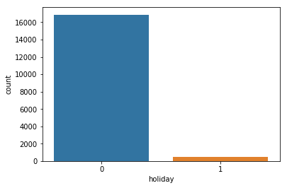

```python
sns.countplot(x = 'holiday', data = df)
```

### season-count plot

It can be said from the graph that

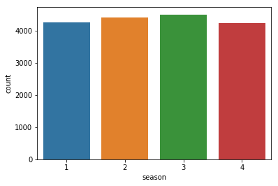

```python
sns.countplot(x = 'season', data = df)
```

### weather situation-count plot

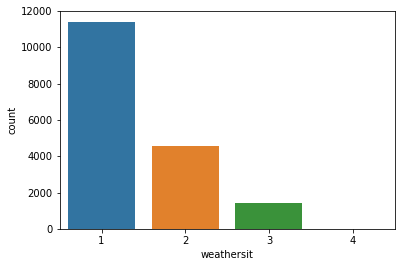

```python
sns.countplot(x = 'weathersit', data = df)
```

### normalised feeling temperature-count plot

From the graph we may say

1. normalised feeling temperature of 0.5 approximately has maximum count of 2500
2. as the normalised feeling temperature increases its count increases then reaches maximum and the decreases at similar proportion

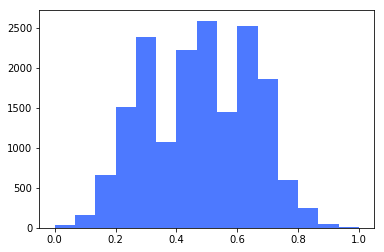

```python
plt.hist(x = 'atemp' , data = df , bins =15,color='#4d79ff' )
plt.show()
```

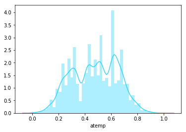

```python
sns.distplot(df['atemp'],color='#33d6ff')
```

### humidity - count plot

We can say that the graph reveals following details

1. Highest humidity has been observed at an interval of 0.65-0.75

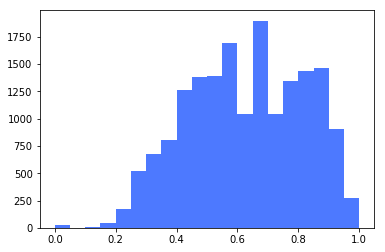

```python
plt.hist(x = 'hum' , data = df , bins =20,color='#4d79ff' )
plt.show()
```

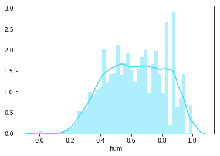

```python
g=sns.distplot(df['hum'],color='#33d6ff')
```

## Bivariate Analysis

Bi" means two while "variate" means variable.So Bivariate means two variables. Hence Bivariate Analysis works on two different variables showing how they are correlated. Bivariate analysis shows us the dependency of one attribute on another.

Let's see the correlation between two variables:

```python
df.corr()
```

|  | instant | season | yr | mnth | hr | holiday | weekday | workingday | weathersit | temp | atemp | hum | windspeed | casual | registered | cnt |
| --- | --- | --- | --- | --- | --- | --- | --- | --- | --- | --- | --- | --- | --- | --- | --- | --- |
| instant | 1.000000 | 0.404046 | 0.866014 | 0.489164 | -0.004775 | 0.014723 | 0.001357 | -0.003416 | -0.014198 | 0.136178 | 0.137615 | 0.009577 | -0.074505 | 0.158295 | 0.282046 | 0.278379 |
| season | 0.404046 | 1.000000 | -0.010742 | 0.830386 | -0.006117 | -0.009585 | -0.002335 | 0.013743 | -0.014524 | 0.312025 | 0.319380 | 0.150625 | -0.149773 | 0.120206 | 0.174226 | 0.178056 |
| yr | 0.866014 | -0.010742 | 1.000000 | -0.010473 | -0.003867 | 0.006692 | -0.004485 | -0.002196 | -0.019157 | 0.040913 | 0.039222 | -0.083546 | -0.008740 | 0.142779 | 0.253684 | 0.250495 |
| mnth | 0.489164 | 0.830386 | -0.010473 | 1.000000 | -0.005772 | 0.018430 | 0.010400 | -0.003477 | 0.005400 | 0.201691 | 0.208096 | 0.164411 | -0.135386 | 0.068457 | 0.122273 | 0.120638 |
| hr | -0.004775 | -0.006117 | -0.003867 | -0.005772 | 1.000000 | 0.000479 | -0.003498 | 0.002285 | -0.020203 | 0.137603 | 0.133750 | -0.276498 | 0.137252 | 0.301202 | 0.374141 | 0.394071 |
| holiday | 0.014723 | -0.009585 | 0.006692 | 0.018430 | 0.000479 | 1.000000 | -0.102088 | -0.252471 | -0.017036 | -0.027340 | -0.030973 | -0.010588 | 0.003988 | 0.031564 | -0.047345 | -0.030927 |
| weekday | 0.001357 | -0.002335 | -0.004485 | 0.010400 | -0.003498 | -0.102088 | 1.000000 | 0.035955 | 0.003311 | -0.001795 | -0.008821 | -0.037158 | 0.011502 | 0.032721 | 0.021578 | 0.026900 |
| workingday | -0.003416 | 0.013743 | -0.002196 | -0.003477 | 0.002285 | -0.252471 | 0.035955 | 1.000000 | 0.044672 | 0.055390 | 0.054667 | 0.015688 | -0.011830 | -0.300942 | 0.134326 | 0.030284 |
| weathersit | -0.014198 | -0.014524 | -0.019157 | 0.005400 | -0.020203 | -0.017036 | 0.003311 | 0.044672 | 1.000000 | -0.102640 | -0.105563 | 0.418130 | 0.026226 | -0.152628 | -0.120966 | -0.142426 |
| temp | 0.136178 | 0.312025 | 0.040913 | 0.201691 | 0.137603 | -0.027340 | -0.001795 | 0.055390 | -0.102640 | 1.000000 | 0.987672 | -0.069881 | -0.023125 | 0.459616 | 0.335361 | 0.404772 |
| atemp | 0.137615 | 0.319380 | 0.039222 | 0.208096 | 0.133750 | -0.030973 | -0.008821 | 0.054667 | -0.105563 | 0.987672 | 1.000000 | -0.051918 | -0.062336 | 0.454080 | 0.332559 | 0.400929 |
| hum | 0.009577 | 0.150625 | -0.083546 | 0.164411 | -0.276498 | -0.010588 | -0.037158 | 0.015688 | 0.418130 | -0.069881 | -0.051918 | 1.000000 | -0.290105 | -0.347028 | -0.273933 | -0.322911 |
| windspeed | -0.074505 | -0.149773 | -0.008740 | -0.135386 | 0.137252 | 0.003988 | 0.011502 | -0.011830 | 0.026226 | -0.023125 | -0.062336 | -0.290105 | 1.000000 | 0.090287 | 0.082321 | 0.093234 |
| casual | 0.158295 | 0.120206 | 0.142779 | 0.068457 | 0.301202 | 0.031564 | 0.032721 | -0.300942 | -0.152628 | 0.459616 | 0.454080 | -0.347028 | 0.090287 | 1.000000 | 0.506618 | 0.694564 |
| registered | 0.282046 | 0.174226 | 0.253684 | 0.122273 | 0.374141 | -0.047345 | 0.021578 | 0.134326 | -0.120966 | 0.335361 | 0.332559 | -0.273933 | 0.082321 | 0.506618 | 1.000000 | 0.972151 |
| cnt | 0.278379 | 0.178056 | 0.250495 | 0.120638 | 0.394071 | -0.030927 | 0.026900 | 0.030284 | -0.142426 | 0.404772 | 0.400929 | -0.322911 | 0.093234 | 0.694564 | 0.972151 | 1.000000 |

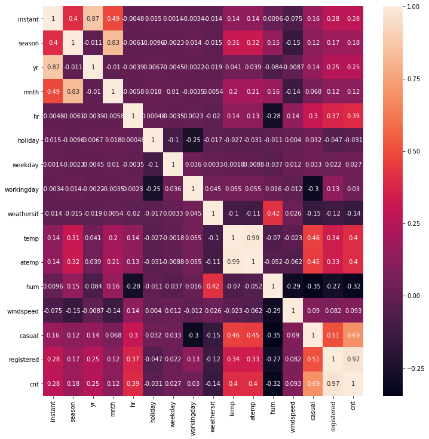

```python
# annot=True shows the relation magnitude(the numbers on each block) between two attributes
# plt.figure(figsize=(1,10)) resizes the figure and it should be written before creating the plot.
plt.figure(figsize=(12,12))
sns.heatmap(df.corr(), annot=True)
plt.show()
```

### temperature-season plot

We can draw following inferences from the graph

1. Highest temperature is in season 3(Fall)
2. Lowest temperature is in season 1(Spring)
3. There is positive correlation between season and temperature

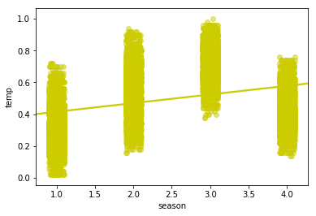

```python
sns.regplot(y = 'temp',x = 'season',data = df , x_jitter=0.1, scatter_kws={'alpha':0.5},color='#cccc00')
```

### total count-working days plot

The plots can help us derve the following facts:

1. There is a slight positive correlation between working day and bikes renting
2. There are a maximum of 950 borrowers renting bikes on working days

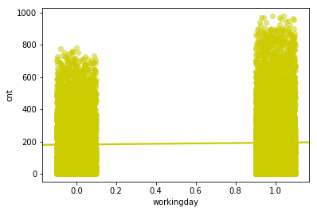

```python
sns.regplot(x= 'workingday',y= 'cnt',data = df , x_jitter=0.1, scatter_kws={'alpha':0.5},color='#cccc00')
```

### hour-total bikes rented count

From the graph we can say that:

1. Highest number of renting is between 17:00 hrs - 18:00 hrs
2. Lowest number of bikes renting is between 4:00 hrs to 5:00 hrs
3. There is positive correlation between total renting and hour of a day

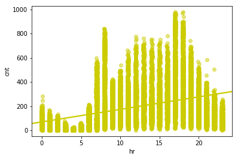

```python
sns.regplot(y = 'cnt',x = 'hr',data = df , x_jitter=0.1, scatter_kws={'alpha':0.5},color='#cccc00')
```

## Multivariate Analysis

"Multi" means many, "variate" means variable. Therefor Multi Variate analysis means analysison the basis of many variable. Here multiple different attributes are taken into account while reaching to a conclusion. It gives better result as compared to Single variate or Bi variate analysis because there are multiple factors taken together to reach to an inference in Multi variate analysis

### holiday-temperature-total count plot

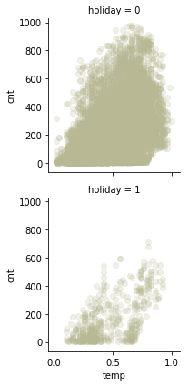

```python
grid=sns.FacetGrid(df,row='holiday')
grid.map(plt.scatter,'temp','cnt',alpha=0.2,color='#b8b894')
```

### month-humidity-total count plot

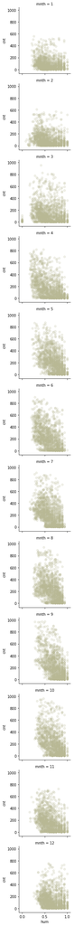

```python
grid=sns.FacetGrid(df,row='mnth')
grid.map(plt.scatter,'hum','cnt',alpha=0.2,color='#b8b894')
```

### season-humidity-total count plot

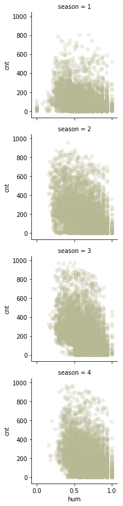

```python
grid=sns.FacetGrid(df,row='season')
grid.map(plt.scatter,'hum','cnt',alpha=0.2,color='#b8b894')
```